# Business Analytics - Final Project

Critical Thinking Group 5

Arindam Barman

Mohamed Elmoudni

Shazia Khan

Kishore Prasad

\newpage

# Overview

The data set contains approximately 41188 obs. of 21 variables.  
This dataset is based on “Bank Marketing” UCI dataset (please check the description at: http://archive.ics.uci.edu/ml/datasets/Bank+Marketing). The data is enriched by the addition of five new social and economic features/attributes (national wide indicators from a ~10M population country), published by the Banco de Portugal and publicly available at: https://www.bportugal.pt/estatisticasweb.\

The binary classification goal is to predict if the client will subscribe a bank term deposit (variable y).

# 1 Data Exploration Analysis

In section we will explore and gain some insights into the dataset by pursuing the below high level steps and inquiries:  
-Variable identification  
-Missing values and Unique Values

## 1.1 Variable identification

First let’s display and examine the data dictionary or the data columns as shown in table 1

Variable Description

[output not shown]

We notice that the variables are numerical, categorical and binary. The responce variable y is binary.

Binomial Logistic regression is the appropriate regression analysis to conduct when the dependent variable is dichotomous (binary). Like all regression analyses, the logistic regression is a predictive analysis. Logistic regression is used to describe data and to explain the relationship between one dependent binary variable and one or more metric (interval or ratio scale) independent variables.

## 1.2 Missing values and Unique Values

Missing Values

|  | Missing Values |
| --- | --- |
| age | 0 |
| job | 0 |
| marital | 0 |
| education | 0 |
| default | 0 |
| housing | 0 |
| loan | 0 |
| contact | 0 |
| month | 0 |
| day_of_week | 0 |
| duration | 0 |
| campaign | 0 |
| pdays | 0 |
| previous | 0 |
| poutcome | 0 |
| emp.var.rate | 0 |
| cons.price.idx | 0 |
| cons.conf.idx | 0 |
| euribor3m | 0 |
| nr.employed | 0 |
| y | 0 |

Unique Values

|  | Unique Values |
| --- | --- |
| age | 78 |
| job | 12 |
| marital | 4 |
| education | 8 |
| default | 3 |
| housing | 3 |
| loan | 3 |
| contact | 2 |
| month | 10 |
| day_of_week | 5 |
| duration | 1544 |
| campaign | 42 |
| pdays | 27 |
| previous | 8 |
| poutcome | 3 |
| emp.var.rate | 10 |
| cons.price.idx | 26 |
| cons.conf.idx | 26 |
| euribor3m | 316 |
| nr.employed | 11 |
| y | 2 |

```
## 'data.frame':    41188 obs. of  21 variables:
##  $ age           : int  56 57 37 40 56 45 59 41 24 25 ...
##  $ job           : Factor w/ 12 levels "admin.","blue-collar",..: 4 8 8 1 8 8 1 2 10 8 ...
##  $ marital       : Factor w/ 4 levels "divorced","married",..: 2 2 2 2 2 2 2 2 3 3 ...
##  $ education     : Factor w/ 8 levels "basic.4y","basic.6y",..: 1 4 4 2 4 3 6 8 6 4 ...
##  $ default       : Factor w/ 3 levels "no","unknown",..: 1 2 1 1 1 2 1 2 1 1 ...
##  $ housing       : Factor w/ 3 levels "no","unknown",..: 1 1 3 1 1 1 1 1 3 3 ...
##  $ loan          : Factor w/ 3 levels "no","unknown",..: 1 1 1 1 3 1 1 1 1 1 ...
##  $ contact       : Factor w/ 2 levels "cellular","telephone": 2 2 2 2 2 2 2 2 2 2 ...
##  $ month         : Factor w/ 10 levels "apr","aug","dec",..: 7 7 7 7 7 7 7 7 7 7 ...
##  $ day_of_week   : Factor w/ 5 levels "fri","mon","thu",..: 2 2 2 2 2 2 2 2 2 2 ...
##  $ duration      : int  261 149 226 151 307 198 139 217 380 50 ...
##  $ campaign      : int  1 1 1 1 1 1 1 1 1 1 ...
##  $ pdays         : int  999 999 999 999 999 999 999 999 999 999 ...
##  $ previous      : int  0 0 0 0 0 0 0 0 0 0 ...
##  $ poutcome      : Factor w/ 3 levels "failure","nonexistent",..: 2 2 2 2 2 2 2 2 2 2 ...
##  $ emp.var.rate  : num  1.1 1.1 1.1 1.1 1.1 1.1 1.1 1.1 1.1 1.1 ...
##  $ cons.price.idx: num  94 94 94 94 94 ...
##  $ cons.conf.idx : num  -36.4 -36.4 -36.4 -36.4 -36.4 -36.4 -36.4 -36.4 -36.4 -36.4 ...
##  $ euribor3m     : num  4.86 4.86 4.86 4.86 4.86 ...
##  $ nr.employed   : num  5191 5191 5191 5191 5191 ...
##  $ y             : Factor w/ 2 levels "no","yes": 1 1 1 1 1 1 1 1 1 1 ...
```

# 2 Data Preparation

-Convert Binary to 0 and 1  
-Create dummy variables  
-Data Summary Analysis  
-Correlation of Variables with y

## 2.1 Convert Binary yes and no to 0 and 1

Now in order to prepare the data for modeling, we need to update Yes = 1 and No = 0.

```
## 'data.frame':    41188 obs. of  21 variables:
##  $ age           : int  56 57 37 40 56 45 59 41 24 25 ...
##  $ job           : Factor w/ 12 levels "admin.","blue-collar",..: 4 8 8 1 8 8 1 2 10 8 ...
##  $ marital       : Factor w/ 4 levels "divorced","married",..: 2 2 2 2 2 2 2 2 3 3 ...
##  $ education     : Factor w/ 8 levels "basic.4y","basic.6y",..: 1 4 4 2 4 3 6 8 6 4 ...
##  $ default       : Factor w/ 3 levels "no","unknown",..: 1 2 1 1 1 2 1 2 1 1 ...
##  $ housing       : Factor w/ 3 levels "no","unknown",..: 1 1 3 1 1 1 1 1 3 3 ...
##  $ loan          : Factor w/ 3 levels "no","unknown",..: 1 1 1 1 3 1 1 1 1 1 ...
##  $ contact       : Factor w/ 2 levels "cellular","telephone": 2 2 2 2 2 2 2 2 2 2 ...
##  $ month         : Factor w/ 10 levels "apr","aug","dec",..: 7 7 7 7 7 7 7 7 7 7 ...
##  $ day_of_week   : Factor w/ 5 levels "fri","mon","thu",..: 2 2 2 2 2 2 2 2 2 2 ...
##  $ duration      : int  261 149 226 151 307 198 139 217 380 50 ...
##  $ campaign      : int  1 1 1 1 1 1 1 1 1 1 ...
##  $ pdays         : int  999 999 999 999 999 999 999 999 999 999 ...
##  $ previous      : int  0 0 0 0 0 0 0 0 0 0 ...
##  $ poutcome      : Factor w/ 3 levels "failure","nonexistent",..: 2 2 2 2 2 2 2 2 2 2 ...
##  $ emp.var.rate  : num  1.1 1.1 1.1 1.1 1.1 1.1 1.1 1.1 1.1 1.1 ...
##  $ cons.price.idx: num  94 94 94 94 94 ...
##  $ cons.conf.idx : num  -36.4 -36.4 -36.4 -36.4 -36.4 -36.4 -36.4 -36.4 -36.4 -36.4 ...
##  $ euribor3m     : num  4.86 4.86 4.86 4.86 4.86 ...
##  $ nr.employed   : num  5191 5191 5191 5191 5191 ...
##  $ y             : num  0 0 0 0 0 0 0 0 0 0 ...
```

## 2.2 Create dummy variables

Now we need to create dummy variables to find out the relationship between y variables and dependent variables, for all categorical variables.

## 2.3 Data Summary Analysis

Data Summary

|  | vars | n | mean | sd | median | trimmed | mad |
| --- | --- | --- | --- | --- | --- | --- | --- |
| age | 1 | 41188 | 40.0240604 | 10.4212500 | 38.000 | 39.3033807 | 10.3782000 |
| duration | 2 | 41188 | 258.2850102 | 259.2792488 | 180.000 | 210.6102513 | 139.3644000 |
| campaign | 3 | 41188 | 2.5675925 | 2.7700135 | 2.000 | 1.9914118 | 1.4826000 |
| previous | 4 | 41188 | 0.1729630 | 0.4949011 | 0.000 | 0.0457332 | 0.0000000 |
| emp.var.rate | 5 | 41188 | 0.0818855 | 1.5709597 | 1.100 | 0.2661204 | 0.4447800 |
| cons.price.idx | 6 | 41188 | 93.5756644 | 0.5788400 | 93.749 | 93.5807666 | 0.5633880 |
| cons.conf.idx | 7 | 41188 | -40.5026003 | 4.6281979 | -41.800 | -40.6015356 | 6.5234400 |
| euribor3m | 8 | 41188 | 3.6212908 | 1.7344474 | 4.857 | 3.8055852 | 0.1601208 |
| nr.employed | 9 | 41188 | 5167.0359109 | 72.2515277 | 5191.000 | 5178.4253338 | 55.0044600 |
| y | 10 | 41188 | 0.1126542 | 0.3161734 | 0.000 | 0.0158412 | 0.0000000 |
| job_housemaid | 11 | 41188 | 0.0257357 | 0.1583475 | 0.000 | 0.0000000 | 0.0000000 |
| job_services | 12 | 41188 | 0.0963630 | 0.2950920 | 0.000 | 0.0000000 | 0.0000000 |
| job_admin. | 13 | 41188 | 0.2530349 | 0.4347560 | 0.000 | 0.1913086 | 0.0000000 |
| job_technician | 14 | 41188 | 0.1637127 | 0.3700192 | 0.000 | 0.0796613 | 0.0000000 |
| job_retired | 15 | 41188 | 0.0417597 | 0.2000421 | 0.000 | 0.0000000 | 0.0000000 |
| job_management | 16 | 41188 | 0.0709916 | 0.2568138 | 0.000 | 0.0000000 | 0.0000000 |
| job_unemployed | 17 | 41188 | 0.0246188 | 0.1549623 | 0.000 | 0.0000000 | 0.0000000 |
| job_self-employed | 18 | 41188 | 0.0345003 | 0.1825127 | 0.000 | 0.0000000 | 0.0000000 |
| job_unknown | 19 | 41188 | 0.0080120 | 0.0891518 | 0.000 | 0.0000000 | 0.0000000 |
| job_entrepreneur | 20 | 41188 | 0.0353501 | 0.1846654 | 0.000 | 0.0000000 | 0.0000000 |
| job_student | 21 | 41188 | 0.0212441 | 0.1441986 | 0.000 | 0.0000000 | 0.0000000 |
| marital_single | 22 | 41188 | 0.2808585 | 0.4494240 | 0.000 | 0.2260864 | 0.0000000 |
| marital_divorced | 23 | 41188 | 0.1119744 | 0.3153387 | 0.000 | 0.0149915 | 0.0000000 |
| marital_unknown | 24 | 41188 | 0.0019423 | 0.0440294 | 0.000 | 0.0000000 | 0.0000000 |
| education_illiterate | 25 | 41188 | 0.0004370 | 0.0209007 | 0.000 | 0.0000000 | 0.0000000 |
| education_unknown | 26 | 41188 | 0.0420268 | 0.2006528 | 0.000 | 0.0000000 | 0.0000000 |
| education_primary | 27 | 41188 | 0.1570360 | 0.3638392 | 0.000 | 0.0713159 | 0.0000000 |
| education_tertiary | 28 | 41188 | 0.4227202 | 0.4939977 | 0.000 | 0.4034050 | 0.0000000 |
| contact_cellular | 29 | 41188 | 0.6347480 | 0.4815066 | 1.000 | 0.6684268 | 0.0000000 |
| default_no | 30 | 41188 | 0.7912013 | 0.4064552 | 1.000 | 0.8639840 | 0.0000000 |
| default_yes | 31 | 41188 | 0.0000728 | 0.0085342 | 0.000 | 0.0000000 | 0.0000000 |
| housing_yes | 32 | 41188 | 0.5238419 | 0.4994373 | 1.000 | 0.5298009 | 0.0000000 |
| housing_unknown | 33 | 41188 | 0.0240361 | 0.1531632 | 0.000 | 0.0000000 | 0.0000000 |
| loan_no | 34 | 41188 | 0.8242692 | 0.3805956 | 1.000 | 0.9053168 | 0.0000000 |
| loan_yes | 35 | 41188 | 0.1516947 | 0.3587290 | 0.000 | 0.0646395 | 0.0000000 |
| loan_unknown | 36 | 41188 | 0.0240361 | 0.1531632 | 0.000 | 0.0000000 | 0.0000000 |
| poutcome_failure | 37 | 41188 | 0.1032340 | 0.3042679 | 0.000 | 0.0040665 | 0.0000000 |
| poutcome_success | 38 | 41188 | 0.0333350 | 0.1795119 | 0.000 | 0.0000000 | 0.0000000 |
| month_jun | 39 | 41188 | 0.1291153 | 0.3353316 | 0.000 | 0.0364166 | 0.0000000 |
| month_jul | 40 | 41188 | 0.1741769 | 0.3792662 | 0.000 | 0.0927410 | 0.0000000 |
| month_aug | 41 | 41188 | 0.1499951 | 0.3570710 | 0.000 | 0.0625152 | 0.0000000 |
| month_oct | 42 | 41188 | 0.0174323 | 0.1308770 | 0.000 | 0.0000000 | 0.0000000 |
| month_nov | 43 | 41188 | 0.0995678 | 0.2994265 | 0.000 | 0.0000000 | 0.0000000 |
| month_dec | 44 | 41188 | 0.0044188 | 0.0663276 | 0.000 | 0.0000000 | 0.0000000 |
| month_mar | 45 | 41188 | 0.0132563 | 0.1143717 | 0.000 | 0.0000000 | 0.0000000 |
| month_apr | 46 | 41188 | 0.0639021 | 0.2445814 | 0.000 | 0.0000000 | 0.0000000 |
| month_sep | 47 | 41188 | 0.0138390 | 0.1168238 | 0.000 | 0.0000000 | 0.0000000 |
| day_of_week_tue | 48 | 41188 | 0.1964164 | 0.3972919 | 0.000 | 0.1205390 | 0.0000000 |
| day_of_week_wed | 49 | 41188 | 0.1974847 | 0.3981059 | 0.000 | 0.1218742 | 0.0000000 |
| day_of_week_thu | 50 | 41188 | 0.2093571 | 0.4068547 | 0.000 | 0.1367140 | 0.0000000 |
| day_of_week_fri | 51 | 41188 | 0.1900311 | 0.3923302 | 0.000 | 0.1125577 | 0.0000000 |
| previous_contact | 52 | 41188 | 0.0367826 | 0.1882298 | 0.000 | 0.0000000 | 0.0000000 |

Data Summary (Cont)

|  | min | max | range | skew | kurtosis | se |
| --- | --- | --- | --- | --- | --- | --- |
| age | 17.000 | 98.000 | 81.000 | 0.7846397 | 0.7908857 | 0.0513493 |
| duration | 0.000 | 4918.000 | 4918.000 | 3.2629036 | 20.2442057 | 1.2775632 |
| campaign | 1.000 | 56.000 | 55.000 | 4.7621598 | 36.9732194 | 0.0136489 |
| previous | 0.000 | 7.000 | 7.000 | 3.8317631 | 20.1051076 | 0.0024386 |
| emp.var.rate | -3.400 | 1.400 | 4.800 | -0.7240428 | -1.0627423 | 0.0077407 |
| cons.price.idx | 92.201 | 94.767 | 2.566 | -0.2308708 | -0.8299589 | 0.0028522 |
| cons.conf.idx | -50.800 | -26.900 | 23.900 | 0.3031578 | -0.3587887 | 0.0228048 |
| euribor3m | 0.634 | 5.045 | 4.411 | -0.7091363 | -1.4068549 | 0.0085463 |
| nr.employed | 4963.600 | 5228.100 | 264.500 | -1.0441863 | -0.0040511 | 0.3560096 |
| y | 0.000 | 1.000 | 1.000 | 2.4501517 | 4.0033404 | 0.0015579 |
| job_housemaid | 0.000 | 1.000 | 1.000 | 5.9900255 | 33.8812283 | 0.0007802 |
| job_services | 0.000 | 1.000 | 1.000 | 2.7356021 | 5.4836522 | 0.0014540 |
| job_admin. | 0.000 | 1.000 | 1.000 | 1.1360815 | -0.7093361 | 0.0021422 |
| job_technician | 0.000 | 1.000 | 1.000 | 1.8176306 | 1.3038128 | 0.0018232 |
| job_retired | 0.000 | 1.000 | 1.000 | 4.5813276 | 18.9890235 | 0.0009857 |
| job_management | 0.000 | 1.000 | 1.000 | 3.3409260 | 9.1620092 | 0.0012654 |
| job_unemployed | 0.000 | 1.000 | 1.000 | 6.1352936 | 35.6426931 | 0.0007636 |
| job_self-employed | 0.000 | 1.000 | 1.000 | 5.1008881 | 24.0196428 | 0.0008993 |
| job_unknown | 0.000 | 1.000 | 1.000 | 11.0368168 | 119.8142342 | 0.0004393 |
| job_entrepreneur | 0.000 | 1.000 | 1.000 | 5.0322224 | 23.3238288 | 0.0009099 |
| job_student | 0.000 | 1.000 | 1.000 | 6.6400673 | 42.0915155 | 0.0007105 |
| marital_single | 0.000 | 1.000 | 1.000 | 0.9751869 | -1.0490361 | 0.0022145 |
| marital_divorced | 0.000 | 1.000 | 1.000 | 2.4609486 | 4.0563667 | 0.0015538 |
| marital_unknown | 0.000 | 1.000 | 1.000 | 22.6233213 | 509.8270434 | 0.0002169 |
| education_illiterate | 0.000 | 1.000 | 1.000 | 47.8022616 | 2283.1116468 | 0.0001030 |
| education_unknown | 0.000 | 1.000 | 1.000 | 4.5647225 | 18.8371487 | 0.0009887 |
| education_primary | 0.000 | 1.000 | 1.000 | 1.8852047 | 1.5540345 | 0.0017928 |
| education_tertiary | 0.000 | 1.000 | 1.000 | 0.3128675 | -1.9021601 | 0.0024341 |
| contact_cellular | 0.000 | 1.000 | 1.000 | -0.5596796 | -1.6867997 | 0.0023726 |
| default_no | 0.000 | 1.000 | 1.000 | -1.4328481 | 0.0530549 | 0.0020028 |
| default_yes | 0.000 | 1.000 | 1.000 | 117.1551691 | 13723.6668447 | 0.0000421 |
| housing_yes | 0.000 | 1.000 | 1.000 | -0.0954727 | -1.9909333 | 0.0024609 |
| housing_unknown | 0.000 | 1.000 | 1.000 | 6.2149702 | 36.6267442 | 0.0007547 |
| loan_no | 0.000 | 1.000 | 1.000 | -1.7039679 | 0.9035286 | 0.0018753 |
| loan_yes | 0.000 | 1.000 | 1.000 | 1.9418382 | 1.7707787 | 0.0017676 |
| loan_unknown | 0.000 | 1.000 | 1.000 | 6.2149702 | 36.6267442 | 0.0007547 |
| poutcome_failure | 0.000 | 1.000 | 1.000 | 2.6079414 | 4.8014749 | 0.0014992 |
| poutcome_success | 0.000 | 1.000 | 1.000 | 5.1991402 | 25.0316666 | 0.0008845 |
| month_jun | 0.000 | 1.000 | 1.000 | 2.2119941 | 2.8929884 | 0.0016523 |
| month_jul | 0.000 | 1.000 | 1.000 | 1.7181345 | 0.9520092 | 0.0018688 |
| month_aug | 0.000 | 1.000 | 1.000 | 1.9603741 | 1.8431112 | 0.0017594 |
| month_oct | 0.000 | 1.000 | 1.000 | 7.3741903 | 52.3799548 | 0.0006449 |
| month_nov | 0.000 | 1.000 | 1.000 | 2.6745954 | 5.1535859 | 0.0014754 |
| month_dec | 0.000 | 1.000 | 1.000 | 14.9430876 | 221.3012387 | 0.0003268 |
| month_mar | 0.000 | 1.000 | 1.000 | 8.5114073 | 70.4457653 | 0.0005636 |
| month_apr | 0.000 | 1.000 | 1.000 | 3.5659885 | 10.7165344 | 0.0012051 |
| month_sep | 0.000 | 1.000 | 1.000 | 8.3227782 | 67.2702700 | 0.0005756 |
| day_of_week_tue | 0.000 | 1.000 | 1.000 | 1.5282275 | 0.3354874 | 0.0019576 |
| day_of_week_wed | 0.000 | 1.000 | 1.000 | 1.5197359 | 0.3096048 | 0.0019616 |
| day_of_week_thu | 0.000 | 1.000 | 1.000 | 1.4286962 | 0.0411737 | 0.0020047 |
| day_of_week_fri | 0.000 | 1.000 | 1.000 | 1.5801046 | 0.4967426 | 0.0019332 |
| previous_contact | 0.000 | 1.000 | 1.000 | 4.9217092 | 22.2237610 | 0.0009275 |

## 2.4 Correlation of Variables with y

Now we will produce the correlation table between the independent variables and the dependent variable

Variable Correlation

| y | 1.0000000 |
| --- | --- |
| duration | 0.4052738 |
| previous_contact | 0.3248767 |
| poutcome_success | 0.3162694 |
| previous | 0.2301810 |
| contact_cellular | 0.1447731 |
| month_mar | 0.1440140 |
| month_oct | 0.1373659 |
| month_sep | 0.1260674 |
| default_no | 0.0993445 |
| job_student | 0.0939550 |
| job_retired | 0.0922208 |
| month_dec | 0.0793034 |
| month_apr | 0.0761364 |
| cons.conf.idx | 0.0548779 |
| marital_single | 0.0541335 |
| education_tertiary | 0.0471911 |
| poutcome_failure | 0.0317987 |
| job_admin. | 0.0314260 |
| age | 0.0303988 |
| education_unknown | 0.0214301 |
| job_unemployed | 0.0147519 |
| day_of_week_thu | 0.0138884 |
| housing_yes | 0.0117429 |
| day_of_week_tue | 0.0080461 |
| education_illiterate | 0.0072462 |
| day_of_week_wed | 0.0063020 |
| marital_unknown | 0.0052108 |
| loan_no | 0.0051231 |
| job_unknown | -0.0001515 |
| job_management | -0.0004189 |
| housing_unknown | -0.0022700 |
| loan_unknown | -0.0022700 |
| default_yes | -0.0030410 |
| loan_yes | -0.0044661 |
| job_self-employed | -0.0046625 |
| job_technician | -0.0061486 |
| job_housemaid | -0.0065049 |
| day_of_week_fri | -0.0069963 |
| month_aug | -0.0088126 |
| month_jun | -0.0091818 |
| marital_divorced | -0.0106080 |
| month_nov | -0.0117959 |
| job_entrepreneur | -0.0166439 |
| education_primary | -0.0237753 |
| month_jul | -0.0322301 |
| job_services | -0.0323009 |
| campaign | -0.0663574 |
| cons.price.idx | -0.1362112 |
| emp.var.rate | -0.2983344 |
| euribor3m | -0.3077714 |
| nr.employed | -0.3546783 |

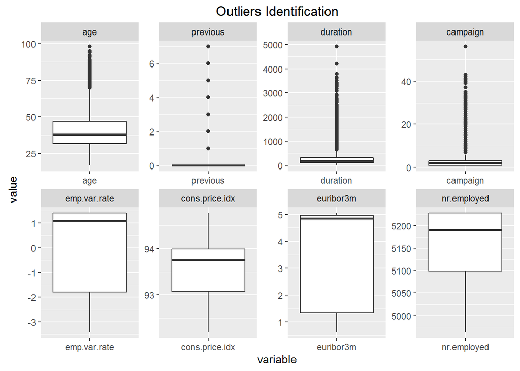

## 2.6 Analysis the link function

In this section, we will investigate how our initial data aligns with a typical logistic model plot.

Recall the Logistic Regression is part of a larger class of algorithms known as Generalized Linear Model (glm). The fundamental equation of generalized linear model is:

$g(E(y)) = a+ Bx_1+B_2x_2+ B_3x_3+...$

where, g() is the link function, E(y) is the expectation of target variable and $B_0 + B_1x_1 + B_2x_2+B_3x_3$ is the linear predictor ( $B_0,B_1,B_2, B_3$ to be predicted). The role of link function is to ‘link’ the expectation of y to linear predictor.

In logistic regression, we are only concerned about the probability of outcome dependent variable ( success or failure). As described above, g() is the link function. This function is established using two things: Probability of Success (p) and Probability of Failure (1-p). p should meet following criteria: It must always be positive (since p >= 0) It must always be less than equals to 1 (since p <= 1).

Now let’s investigate how our initial data model aligns with the above criteria. In other words, we will plot regression model plots for each variable and compare it to a typical logistic model plot:

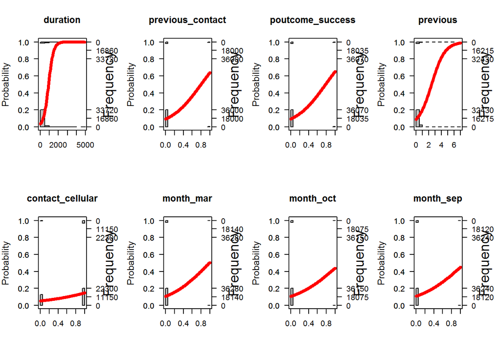

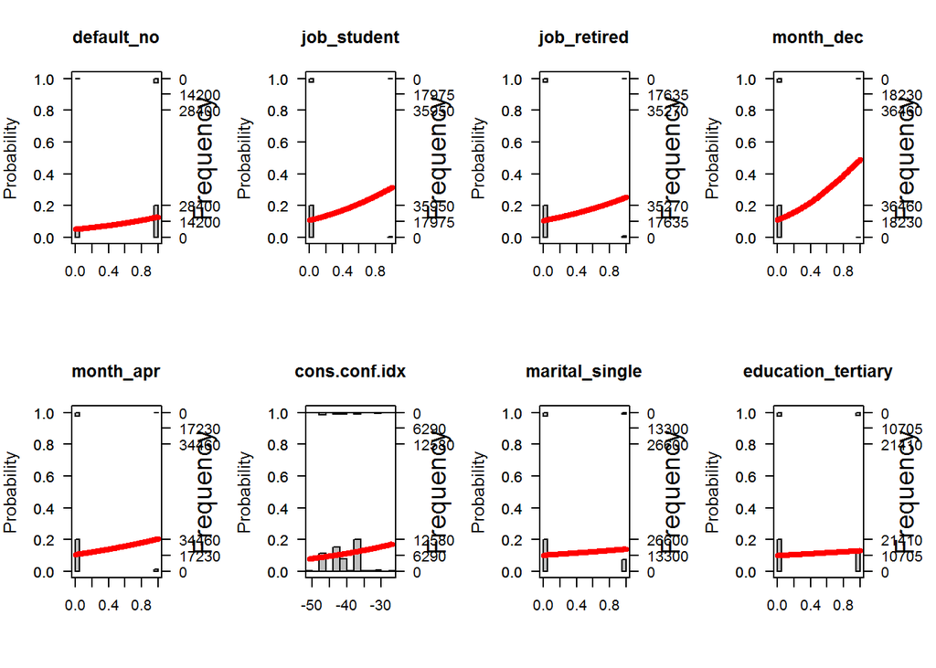

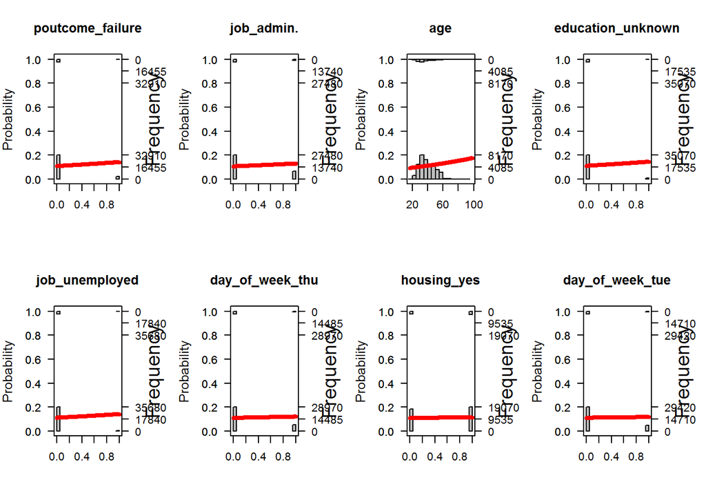

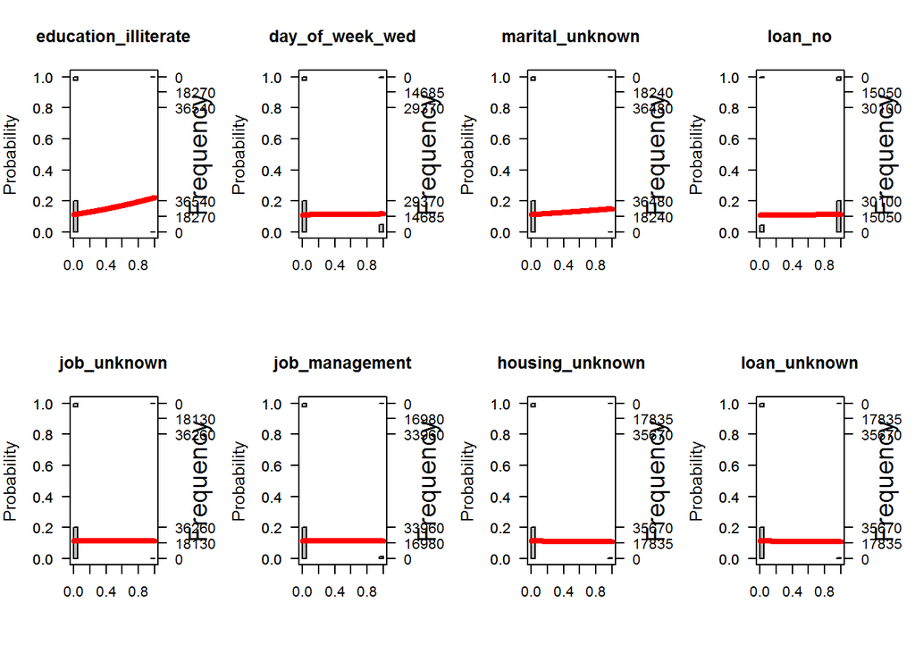

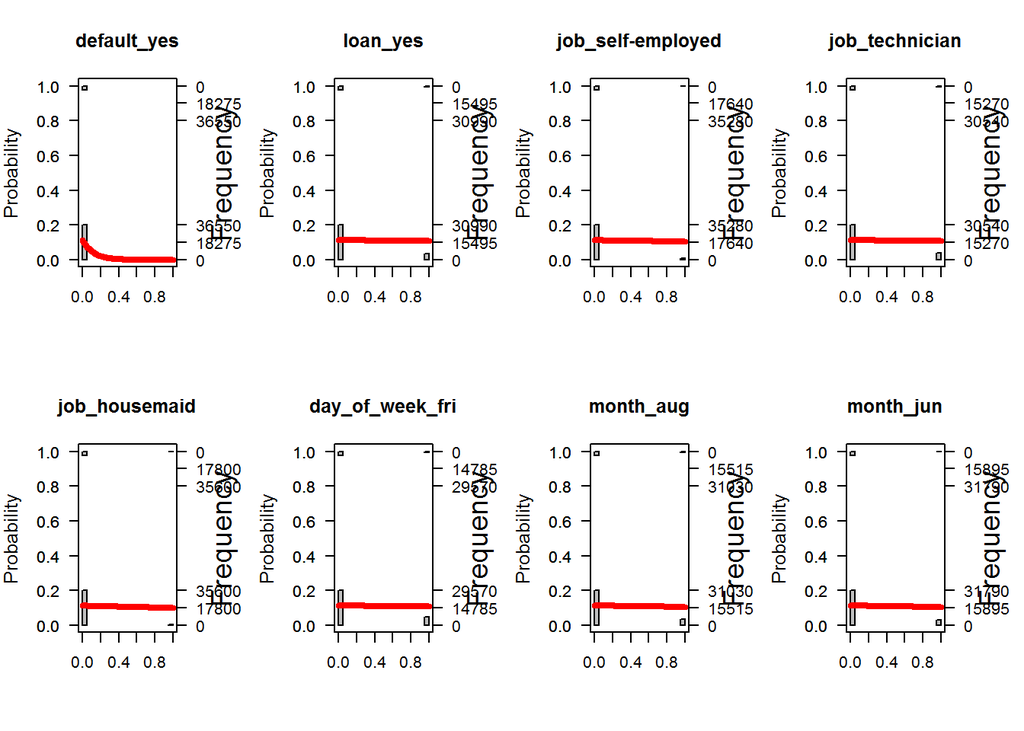

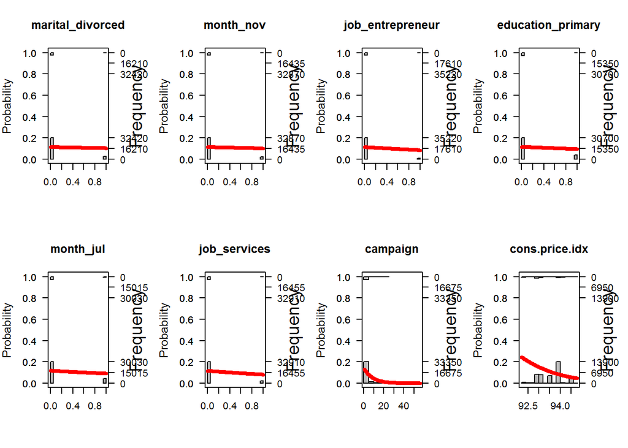

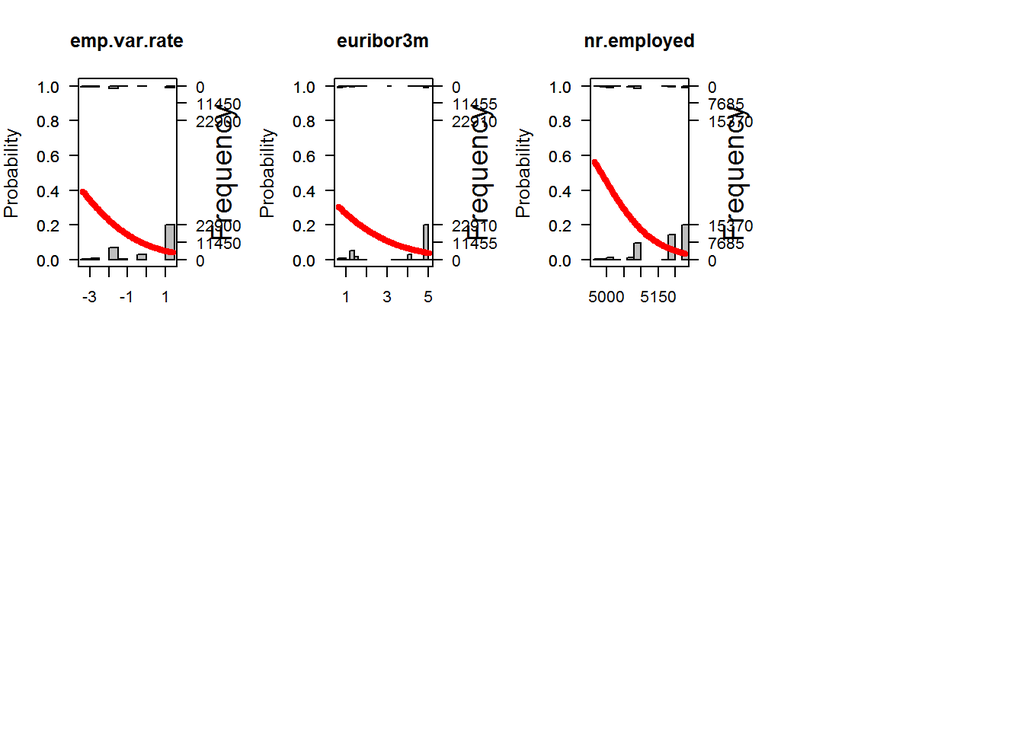

## 2.7 Interpretation

You can see that the probability of y increases as age increases, duration of the call increses